# Exploring Bacteria

Pavlov Alexander

20 декабря 2018 г

# Getting ready

This time we are going to conduct study concerning bacteria number of colonies forming units (cfu’s) of airborne bacteria in the air in and around Graz.

```r
library("readxl")
library("RColorBrewer")
library("MASS")
library("lme4")
pal<-brewer.pal(8,"Set3")
```

# Access Data

You can find the data either in http://www.stat.tugraz. at/courses/files/BacteriaData.xlsx (sheet bacteria) or by clicking on Bacteria Data at http://www.stat.tugraz.at/courses/glmLjubljana.html (only for those of you experiencing troubles with the use of read.xls from within R). The data resulted from a one year study in which bacteria/fungi (actually the number of colonies forming units, cfu’s) in the outdoor air were monitored at 7 di erent sites that can be characterized as follows:

1. village zone, near big farms with liquid manure pits and dung-hills;
2. grassland and arable land, without buildings;
3. suburban area with one-family houses and small farms;
4. busy crossing, near a slaughter-house;
5. public park on top of the Schloberg in the center of Graz;
6. living area with apartment buildings and gardens;
7. as for (f) but with compost arrangements.

Let us load the data into R:

```r
setwd("C:/Users/pavlov-aa/Desktop/GLM Multilevel")
ds<-read_xlsx("bacteriaData.xlsx")
ds<-data.frame(ds)
```

# Data Manipulation

Now let’s prepare dataset for analysis: 1) Date and Site variables to factors 2) Create dependent variables of interest: “bac” and “fun” as sums of bi and fi 3) Check the structure

```r
ds[,1]<-as.factor(ds[,1])
ds[,2]<-as.factor(ds[,2])

ds[,"bac"]<-ds[,"b1"]+ds[,"b2"]+ds[,"b3"]+ds[,"b4"]+ds[,"b5"]+ds[,"b6"]
ds[,"fun"]<-ds[,"f1"]+ds[,"f2"]+ds[,"f3"]+ds[,"f4"]+ds[,"f5"]+ds[,"f6"]

str(ds)
```

```
## 'data.frame':    178 obs. of  18 variables:
##  $ date: Factor w/ 26 levels "2.05","3.01",..: 8 8 8 8 8 8 8 20 20 20 ...
##  $ site: Factor w/ 7 levels "1","2","3","4",..: 1 2 3 4 5 6 7 1 2 3 ...
##  $ humi: num  31 32 28 28 28 29 23 48 46 44 ...
##  $ temp: num  13 9 8 9 11 10 10 6 7 8 ...
##  $ b1  : num  17 10 5 2 8 2 1 10 4 9 ...
##  $ b2  : num  17 6 0 1 11 1 0 11 1 10 ...
##  $ b3  : num  19 2 3 4 11 0 0 8 1 3 ...
##  $ b4  : num  10 16 2 4 2 2 1 10 0 4 ...
##  $ b5  : num  17 7 8 4 3 1 1 4 1 16 ...
##  $ b6  : num  21 2 1 0 8 1 0 7 1 11 ...
##  $ f1  : num  10 12 7 10 2 0 0 4 4 10 ...
##  $ f2  : num  4 6 1 3 1 1 2 3 2 2 ...
##  $ f3  : num  1 7 0 3 4 0 2 7 1 9 ...
##  $ f4  : num  0 4 3 16 13 2 3 6 13 7 ...
##  $ f5  : num  4 2 4 6 10 2 4 7 9 22 ...
##  $ f6  : num  1 2 0 0 3 0 0 9 3 5 ...
##  $ bac : num  101 43 19 15 43 7 3 50 8 53 ...
##  $ fun : num  20 33 15 38 33 5 11 36 32 55 ...
```

Now, structure seems to be okay.

# Linear Regression

After validating models with different parameters we can see 2 best:

```r
lm6<-lm(data=ds, bac~temp+site)
lm7<-lm(data=ds, bac~humi+temp+site)
summary(lm6)
```

```
##
## Call:
## lm(formula = bac ~ temp + site, data = ds)
##
## Residuals:
##     Min      1Q  Median      3Q     Max
## -35.577  -8.521  -3.114   5.131  57.390
##
## Coefficients:
##             Estimate Std. Error t value Pr(>|t|)
## (Intercept)  38.2282     3.5391  10.802  < 2e-16 ***
## temp          0.4140     0.1173   3.530 0.000535 ***
## site2       -19.2861     4.4827  -4.302 2.84e-05 ***
## site3       -18.0456     4.5266  -3.987 9.94e-05 ***
## site4       -23.6720     4.5309  -5.225 5.06e-07 ***
## site5       -28.5451     4.5313  -6.300 2.47e-09 ***
## site6       -33.4614     4.4867  -7.458 4.30e-12 ***
## site7       -31.4335     4.4851  -7.008 5.41e-11 ***
## ---
## Signif. codes:  0 '***' 0.001 '**' 0.01 '*' 0.05 '.' 0.1 ' ' 1
##
## Residual standard error: 16 on 170 degrees of freedom
## Multiple R-squared:  0.3342, Adjusted R-squared:  0.3068
## F-statistic: 12.19 on 7 and 170 DF,  p-value: 1.389e-12
```

```r
summary(lm7)
```

```
##
## Call:
## lm(formula = bac ~ humi + temp + site, data = ds)
##
## Residuals:
##     Min      1Q  Median      3Q     Max
## -34.895  -9.059  -2.984   5.000  55.880
##
## Coefficients:
##              Estimate Std. Error t value Pr(>|t|)
## (Intercept)  41.97948    6.33174   6.630 4.33e-10 ***
## humi         -0.05229    0.07314  -0.715  0.47562
## temp          0.36632    0.13503   2.713  0.00736 **
## site2       -19.21178    4.49031  -4.278 3.14e-05 ***
## site3       -17.95750    4.53481  -3.960  0.00011 ***
## site4       -23.84317    4.54371  -5.248 4.57e-07 ***
## site5       -28.73339    4.54546  -6.321 2.23e-09 ***
## site6       -33.74825    4.51101  -7.481 3.84e-12 ***
## site7       -31.62420    4.49951  -7.028 4.92e-11 ***
## ---
## Signif. codes:  0 '***' 0.001 '**' 0.01 '*' 0.05 '.' 0.1 ' ' 1
##
## Residual standard error: 16.03 on 169 degrees of freedom
## Multiple R-squared:  0.3362, Adjusted R-squared:  0.3048
## F-statistic:  10.7 on 8 and 169 DF,  p-value: 4.018e-12
```

```r
mylm<-lm6
```

lm6 model has a bit less R2, but all the variable are significant and higher R2 adjusted. I think its more safe to drop “humi” and count lm6 as the best linear model without transforming variables.

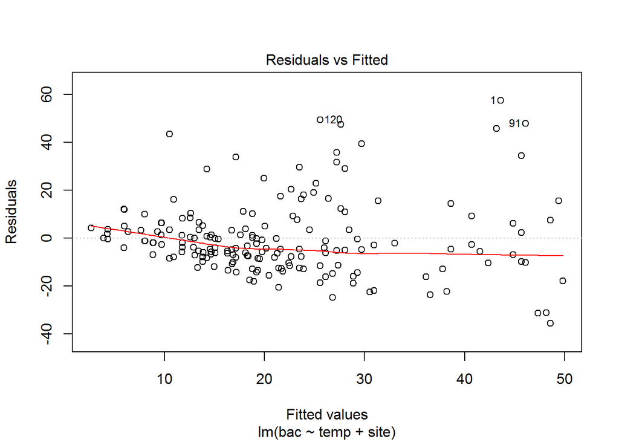

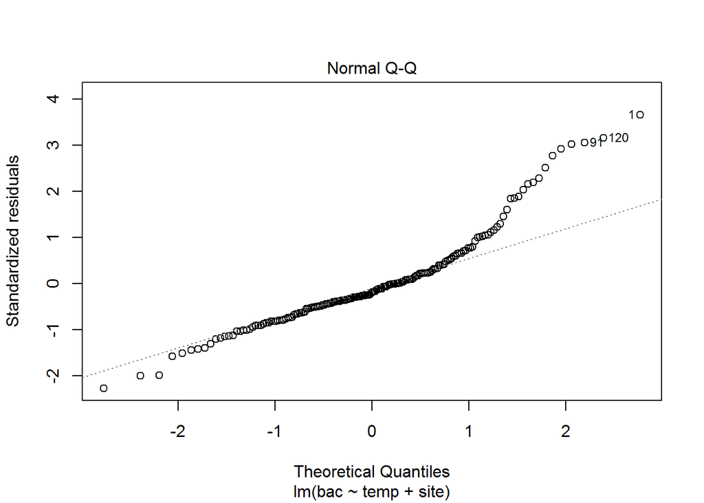

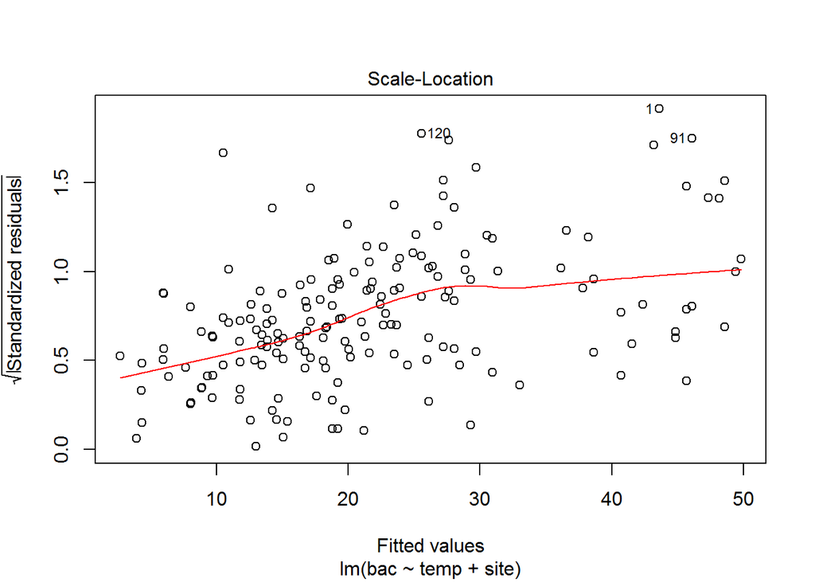

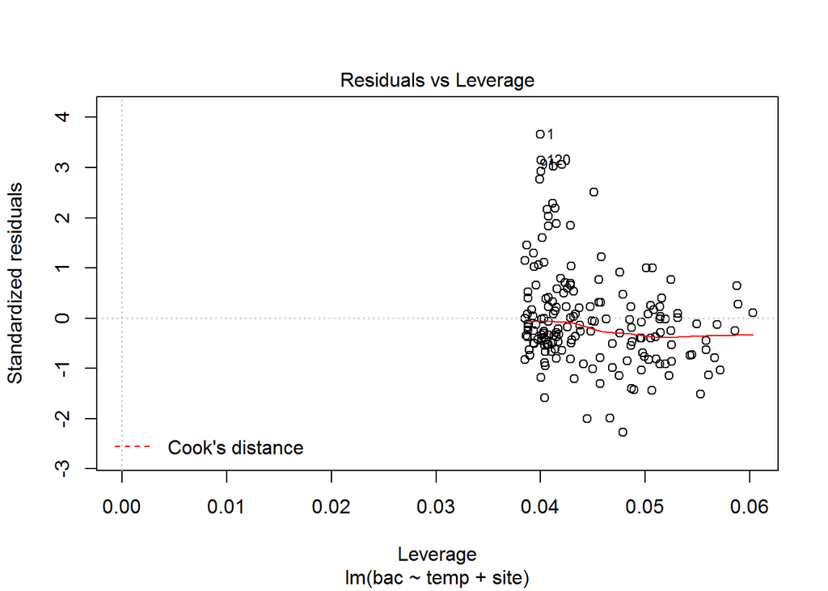

```r
plot(lm6)
```

Normal Q-Q plot shows us that actually there are many observations with high error. Taking into account, that R2 adjusted is about 30% we can say that model is weak.

Also lets look at interdependency between dependent and independent variables:

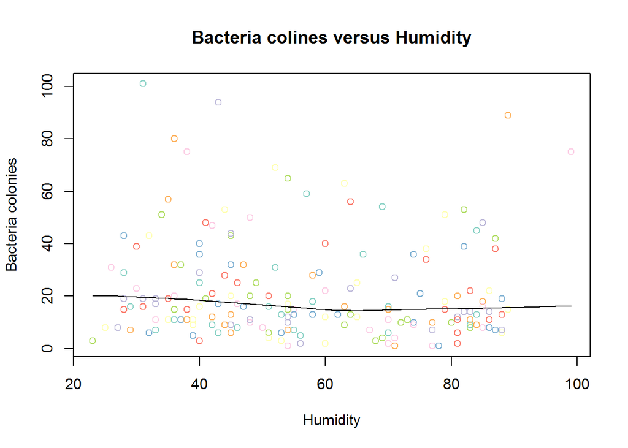

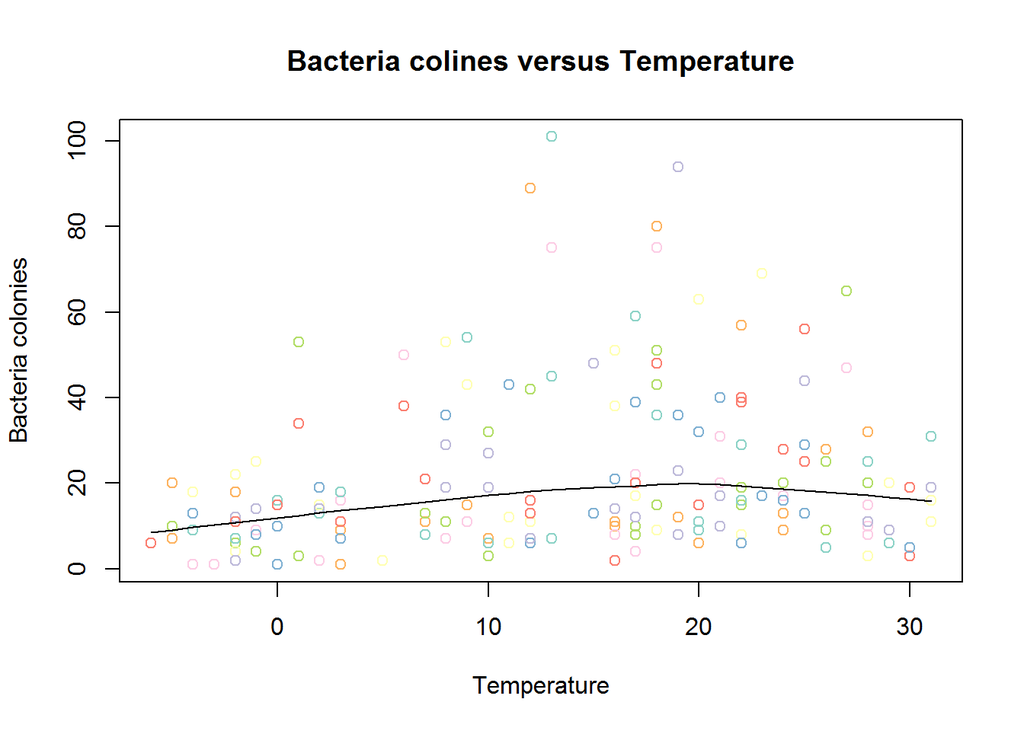

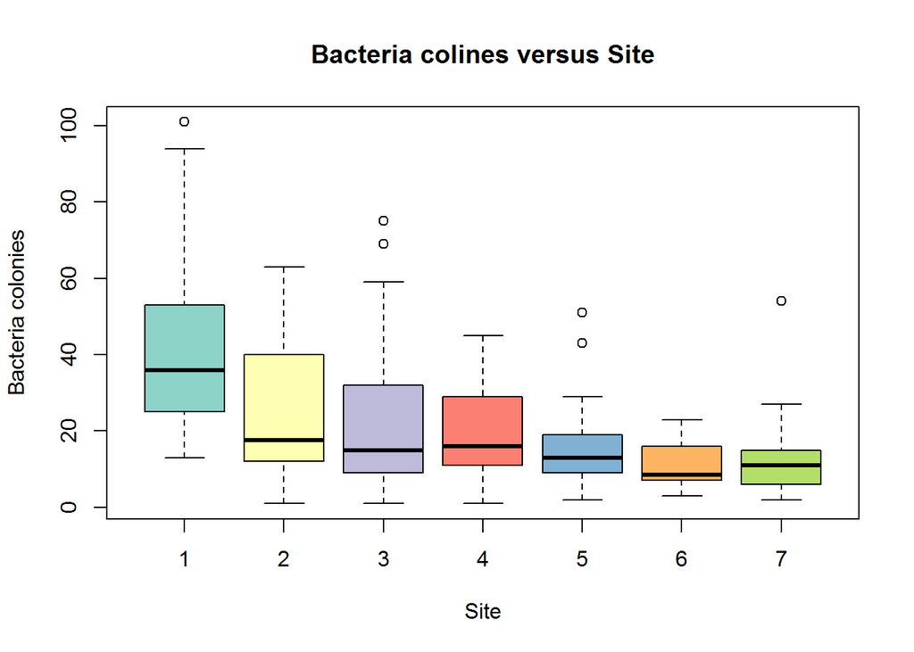

Humidity doesn’t help with explaining Bacteria colonies. More temperature - more colonies and more variation. So, heterogenity exists. In some places the ditribution may distinguish significantly.

And what about humi and temp of degree 2?

```r
lm9<-lm(data=ds, bac~humi+temp+site+I(humi^2)+I(temp^2))
summary(lm9)
```

```
##
## Call:
## lm(formula = bac ~ humi + temp + site + I(humi^2) + I(temp^2),
##     data = ds)
##
## Residuals:
##     Min      1Q  Median      3Q     Max
## -30.944  -9.675  -2.375   6.164  48.239
##
## Coefficients:
##               Estimate Std. Error t value Pr(>|t|)
## (Intercept)  67.332263  12.995518   5.181 6.29e-07 ***
## humi         -1.145577   0.442921  -2.586  0.01055 *
## temp          1.411254   0.325098   4.341 2.45e-05 ***
## site2       -19.705411   4.246622  -4.640 7.00e-06 ***
## site3       -18.512348   4.289622  -4.316 2.72e-05 ***
## site4       -24.124450   4.310984  -5.596 8.82e-08 ***
## site5       -28.966793   4.294592  -6.745 2.39e-10 ***
## site6       -34.321588   4.290233  -8.000 1.98e-13 ***
## site7       -32.201241   4.269187  -7.543 2.81e-12 ***
## I(humi^2)     0.009507   0.003759   2.529  0.01236 *
## I(temp^2)    -0.038703   0.011956  -3.237  0.00146 **
## ---
## Signif. codes:  0 '***' 0.001 '**' 0.01 '*' 0.05 '.' 0.1 ' ' 1
##
## Residual standard error: 15.12 on 167 degrees of freedom
## Multiple R-squared:  0.416,  Adjusted R-squared:  0.381
## F-statistic:  11.9 on 10 and 167 DF,  p-value: 2.287e-15
```

Better results but still R2 adjusted is not high. And suddenly humi became significant. But its not good. Plot showed that humi is uninformative.

What about assumptions?

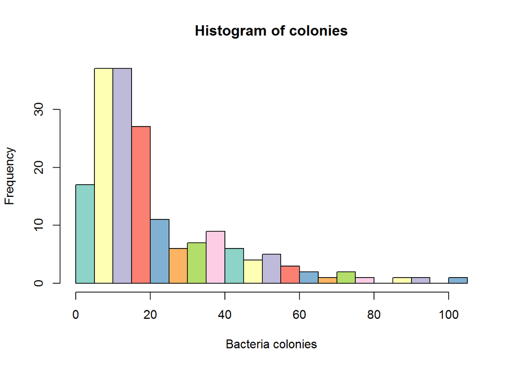

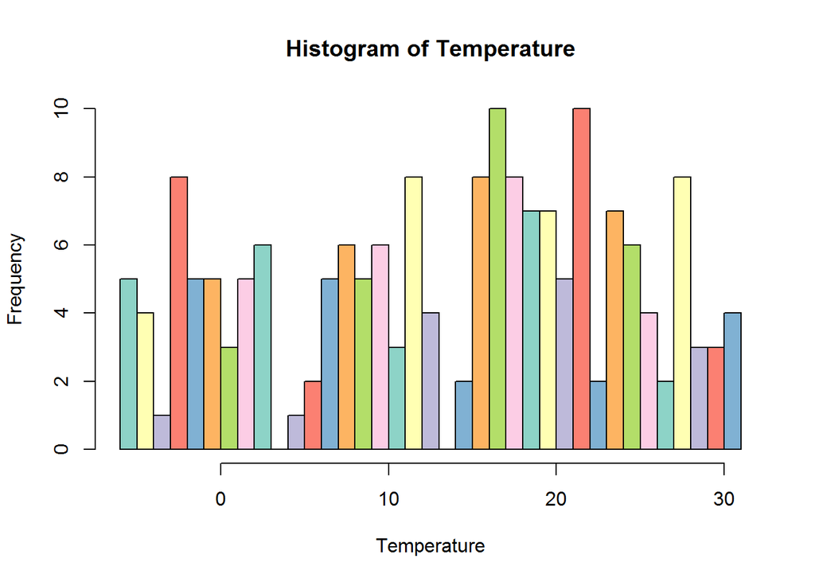

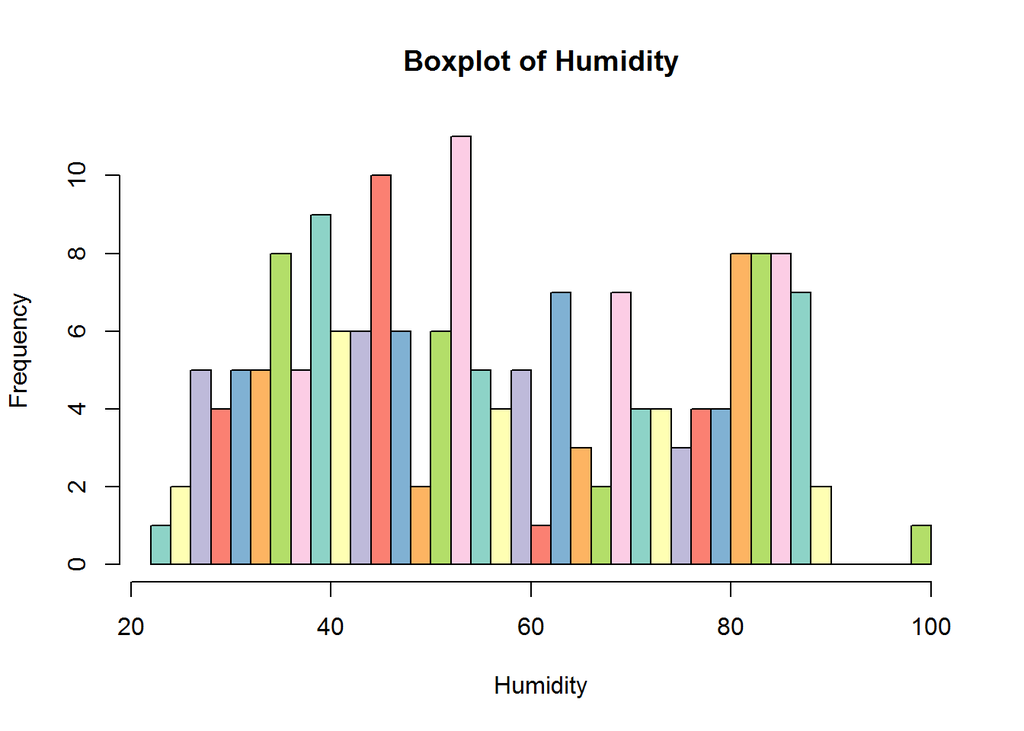

Plot show us, that the distribution is not normal. So, assumptions are not met. And what about residuals?

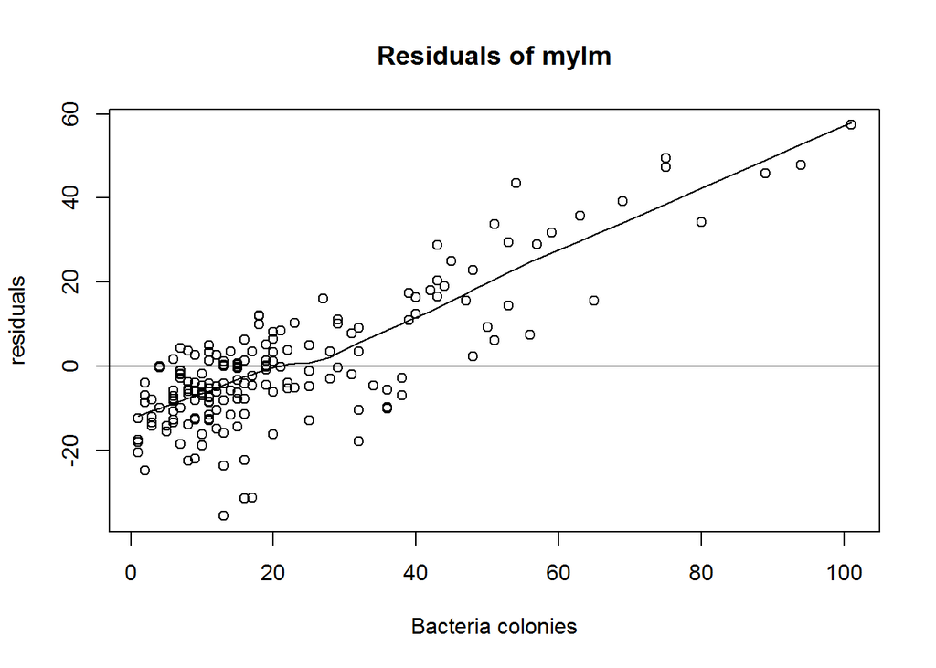

Bad situation. Maybe Box-Cox will help?

# Box-Cox Transformation

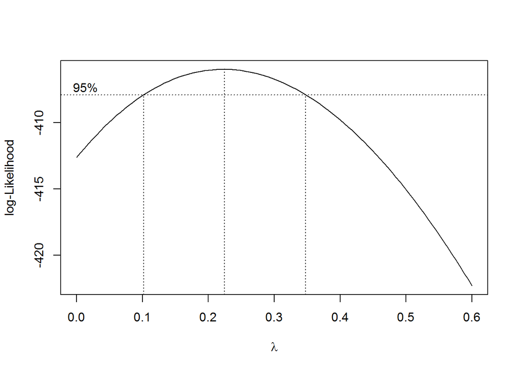

```r
bc<-boxcox(ds$bac~ds$humi+ds$temp+ds$site,lambda=seq(0.0,0.6,length=100),plotit=T)
```

```r
ml.index <- which(bc$y == max(bc$y))
bc$x[ml.index]
```

```
## [1] 0.2242424
```

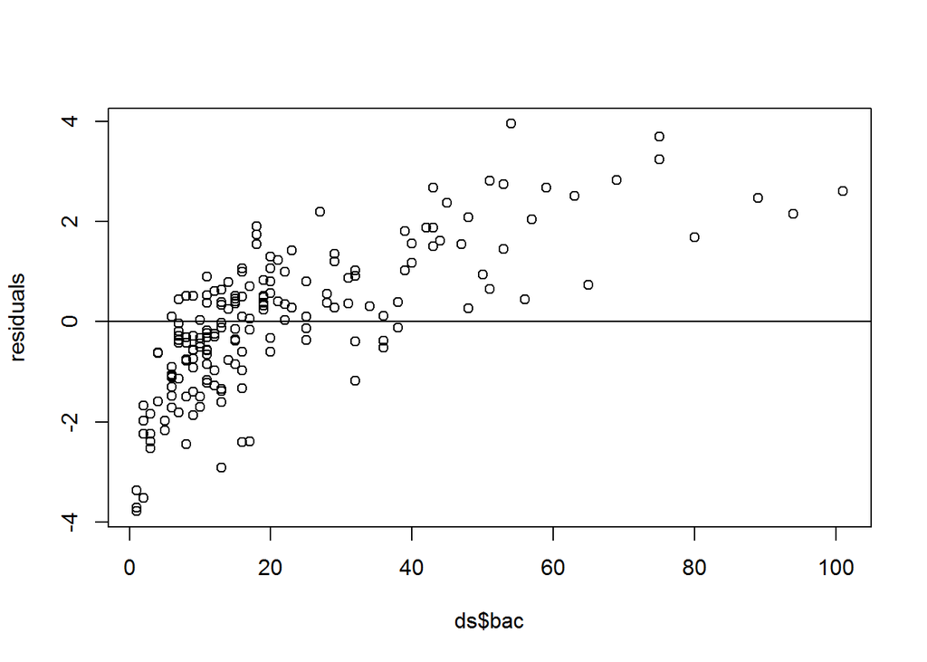

```r
lambda<-1/4

mylmBC<-lm(data=ds, ((bac^lambda)-1)/lambda~humi+temp+site)

plot(ds$bac, residuals(mylmBC), ylab="residuals"); abline(0, 0)
```

```r
summary(mylmBC)
```

```
##
## Call:
## lm(formula = ((bac^lambda) - 1)/lambda ~ humi + temp + site,
##     data = ds)
##
## Residuals:
##     Min      1Q  Median      3Q     Max
## -3.7859 -0.8448  0.0309  0.8294  3.9530
##
## Coefficients:
##              Estimate Std. Error t value Pr(>|t|)
## (Intercept)  5.591495   0.586212   9.538  < 2e-16 ***
## humi        -0.003694   0.006772  -0.546 0.586086
## temp         0.045790   0.012501   3.663 0.000333 ***
## site2       -1.517415   0.415727  -3.650 0.000349 ***
## site3       -1.748356   0.419847  -4.164 4.97e-05 ***
## site4       -1.884636   0.420670  -4.480 1.37e-05 ***
## site5       -2.421419   0.420832  -5.754 4.01e-08 ***
## site6       -3.020457   0.417643  -7.232 1.58e-11 ***
## site7       -2.858500   0.416578  -6.862 1.23e-10 ***
## ---
## Signif. codes:  0 '***' 0.001 '**' 0.01 '*' 0.05 '.' 0.1 ' ' 1
##
## Residual standard error: 1.484 on 169 degrees of freedom
## Multiple R-squared:  0.3407, Adjusted R-squared:  0.3095
## F-statistic: 10.92 on 8 and 169 DF,  p-value: 2.346e-12
```

```r
summary(mylm)
```

```
##
## Call:
## lm(formula = bac ~ temp + site, data = ds)
##
## Residuals:
##     Min      1Q  Median      3Q     Max
## -35.577  -8.521  -3.114   5.131  57.390
##
## Coefficients:
##             Estimate Std. Error t value Pr(>|t|)
## (Intercept)  38.2282     3.5391  10.802  < 2e-16 ***
## temp          0.4140     0.1173   3.530 0.000535 ***
## site2       -19.2861     4.4827  -4.302 2.84e-05 ***
## site3       -18.0456     4.5266  -3.987 9.94e-05 ***
## site4       -23.6720     4.5309  -5.225 5.06e-07 ***
## site5       -28.5451     4.5313  -6.300 2.47e-09 ***
## site6       -33.4614     4.4867  -7.458 4.30e-12 ***
## site7       -31.4335     4.4851  -7.008 5.41e-11 ***
## ---
## Signif. codes:  0 '***' 0.001 '**' 0.01 '*' 0.05 '.' 0.1 ' ' 1
##
## Residual standard error: 16 on 170 degrees of freedom
## Multiple R-squared:  0.3342, Adjusted R-squared:  0.3068
## F-statistic: 12.19 on 7 and 170 DF,  p-value: 1.389e-12
```

With Box-Cox transformation it became a bit better. With lambda =1 and =0 its worse.

```r
lambda<-1
mylmBC2<-lm(data=ds, ((bac^lambda)-1)/lambda~humi+temp+site)
mylmBC3<-lm(data=ds, log(bac)~humi+temp+site)
summary(mylmBC) # best
```

```
##
## Call:
## lm(formula = ((bac^lambda) - 1)/lambda ~ humi + temp + site,
##     data = ds)
##
## Residuals:
##     Min      1Q  Median      3Q     Max
## -3.7859 -0.8448  0.0309  0.8294  3.9530
##
## Coefficients:
##              Estimate Std. Error t value Pr(>|t|)
## (Intercept)  5.591495   0.586212   9.538  < 2e-16 ***
## humi        -0.003694   0.006772  -0.546 0.586086
## temp         0.045790   0.012501   3.663 0.000333 ***
## site2       -1.517415   0.415727  -3.650 0.000349 ***
## site3       -1.748356   0.419847  -4.164 4.97e-05 ***
## site4       -1.884636   0.420670  -4.480 1.37e-05 ***
## site5       -2.421419   0.420832  -5.754 4.01e-08 ***
## site6       -3.020457   0.417643  -7.232 1.58e-11 ***
## site7       -2.858500   0.416578  -6.862 1.23e-10 ***
## ---
## Signif. codes:  0 '***' 0.001 '**' 0.01 '*' 0.05 '.' 0.1 ' ' 1
##
## Residual standard error: 1.484 on 169 degrees of freedom
## Multiple R-squared:  0.3407, Adjusted R-squared:  0.3095
## F-statistic: 10.92 on 8 and 169 DF,  p-value: 2.346e-12
```

```r
summary(mylmBC2) # poor
```

```
##
## Call:
## lm(formula = ((bac^lambda) - 1)/lambda ~ humi + temp + site,
##     data = ds)
##
## Residuals:
##     Min      1Q  Median      3Q     Max
## -34.895  -9.059  -2.984   5.000  55.880
##
## Coefficients:
##              Estimate Std. Error t value Pr(>|t|)
## (Intercept)  40.97948    6.33174   6.472 1.01e-09 ***
## humi         -0.05229    0.07314  -0.715  0.47562
## temp          0.36632    0.13503   2.713  0.00736 **
## site2       -19.21178    4.49031  -4.278 3.14e-05 ***
## site3       -17.95750    4.53481  -3.960  0.00011 ***
## site4       -23.84317    4.54371  -5.248 4.57e-07 ***
## site5       -28.73339    4.54546  -6.321 2.23e-09 ***
## site6       -33.74825    4.51101  -7.481 3.84e-12 ***
## site7       -31.62420    4.49951  -7.028 4.92e-11 ***
## ---
## Signif. codes:  0 '***' 0.001 '**' 0.01 '*' 0.05 '.' 0.1 ' ' 1
##
## Residual standard error: 16.03 on 169 degrees of freedom
## Multiple R-squared:  0.3362, Adjusted R-squared:  0.3048
## F-statistic:  10.7 on 8 and 169 DF,  p-value: 4.018e-12
```

```r
summary(mylmBC3) # poor
```

```
##
## Call:
## lm(formula = log(bac) ~ humi + temp + site, data = ds)
##
## Residuals:
##      Min       1Q   Median       3Q      Max
## -2.54620 -0.41574  0.07593  0.46590  1.87183
##
## Coefficients:
##              Estimate Std. Error t value Pr(>|t|)
## (Intercept)  3.364655   0.308675  10.900  < 2e-16 ***
## humi        -0.001459   0.003566  -0.409 0.682936
## temp         0.025443   0.006583   3.865 0.000158 ***
## site2       -0.704655   0.218904  -3.219 0.001542 **
## site3       -0.892850   0.221074  -4.039 8.14e-05 ***
## site4       -0.876213   0.221507  -3.956 0.000112 ***
## site5       -1.129374   0.221593  -5.097 9.18e-07 ***
## site6       -1.437124   0.219913  -6.535 7.20e-10 ***
## site7       -1.375822   0.219353  -6.272 2.88e-09 ***
## ---
## Signif. codes:  0 '***' 0.001 '**' 0.01 '*' 0.05 '.' 0.1 ' ' 1
##
## Residual standard error: 0.7813 on 169 degrees of freedom
## Multiple R-squared:  0.3116, Adjusted R-squared:  0.279
## F-statistic: 9.561 on 8 and 169 DF,  p-value: 7.031e-11
```

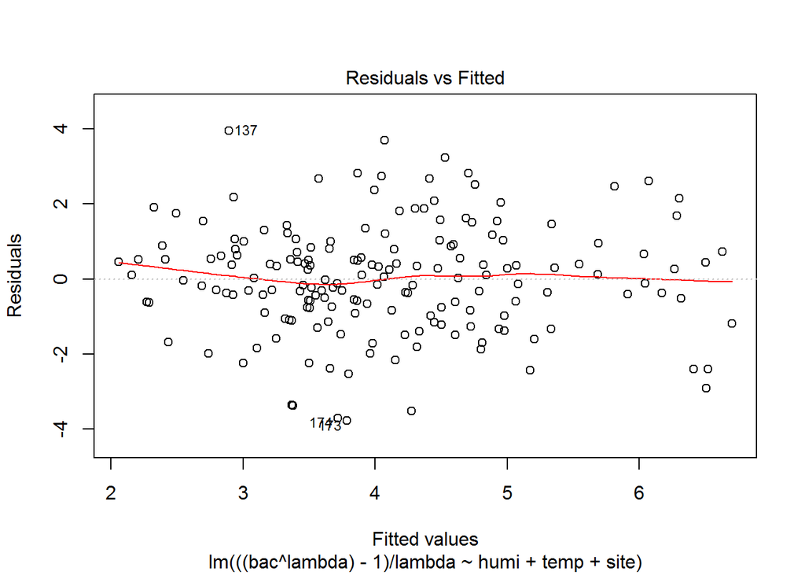

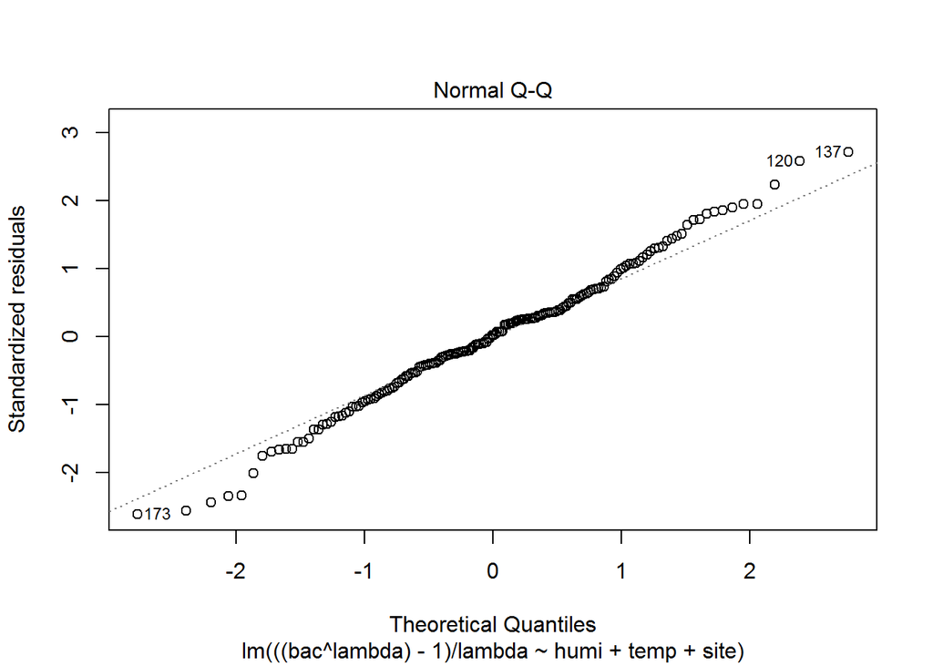

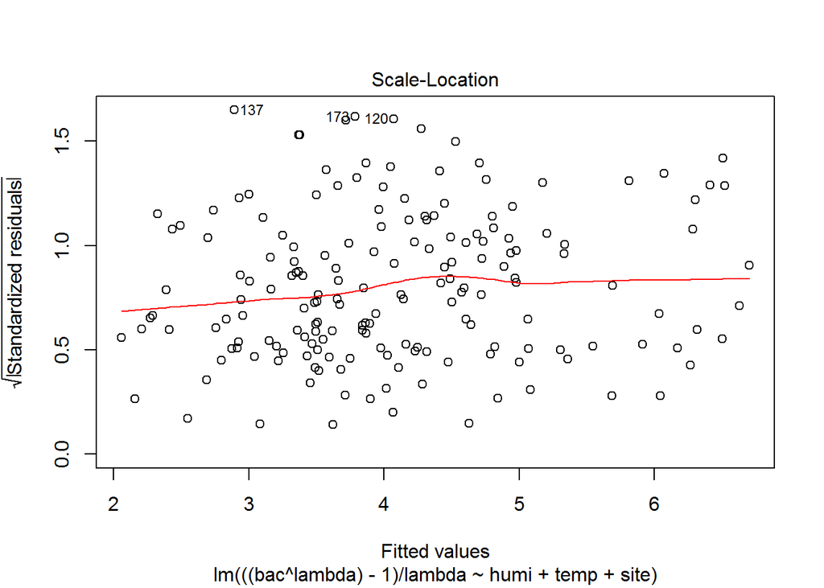

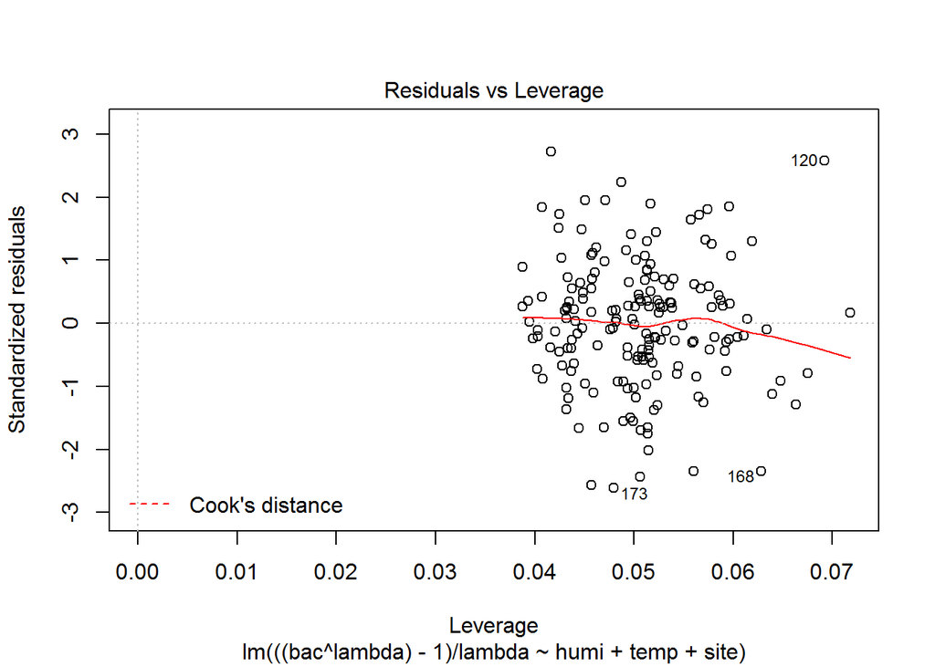

```r
plot(mylmBC)
```

# GLM

```r
myglm<-glm(data=ds,bac~temp+site, family=gaussian(link="log"))
myglm2<-glm(data=ds,bac~temp+site,family=Gamma(link="log"))

summary(myglm)
```

```
##
## Call:
## glm(formula = bac ~ temp + site, family = gaussian(link = "log"),
##     data = ds)
##
## Deviance Residuals:
##     Min       1Q   Median       3Q      Max
## -38.954   -8.760   -3.357    5.354   58.234
##
## Coefficients:
##              Estimate Std. Error t value Pr(>|t|)
## (Intercept)  3.544910   0.110452  32.095  < 2e-16 ***
## temp         0.016218   0.005209   3.113 0.002172 **
## site2       -0.563818   0.145380  -3.878 0.000150 ***
## site3       -0.499467   0.140107  -3.565 0.000473 ***
## site4       -0.755473   0.167992  -4.497 1.27e-05 ***
## site5       -1.058778   0.217455  -4.869 2.55e-06 ***
## site6       -1.431579   0.300611  -4.762 4.08e-06 ***
## site7       -1.263484   0.258530  -4.887 2.35e-06 ***
## ---
## Signif. codes:  0 '***' 0.001 '**' 0.01 '*' 0.05 '.' 0.1 ' ' 1
##
## (Dispersion parameter for gaussian family taken to be 255.8116)
##
##     Null deviance: 65392  on 177  degrees of freedom
## Residual deviance: 43487  on 170  degrees of freedom
## AIC: 1501.9
##
## Number of Fisher Scoring iterations: 7
```

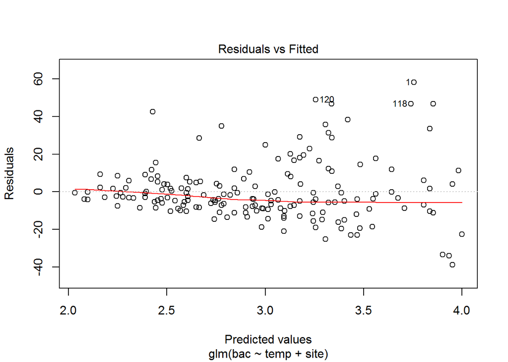

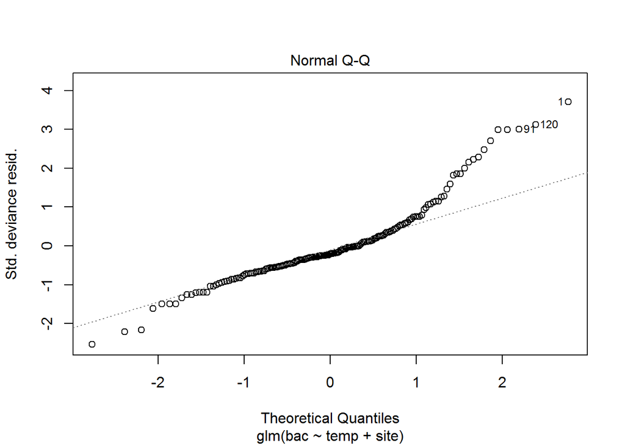

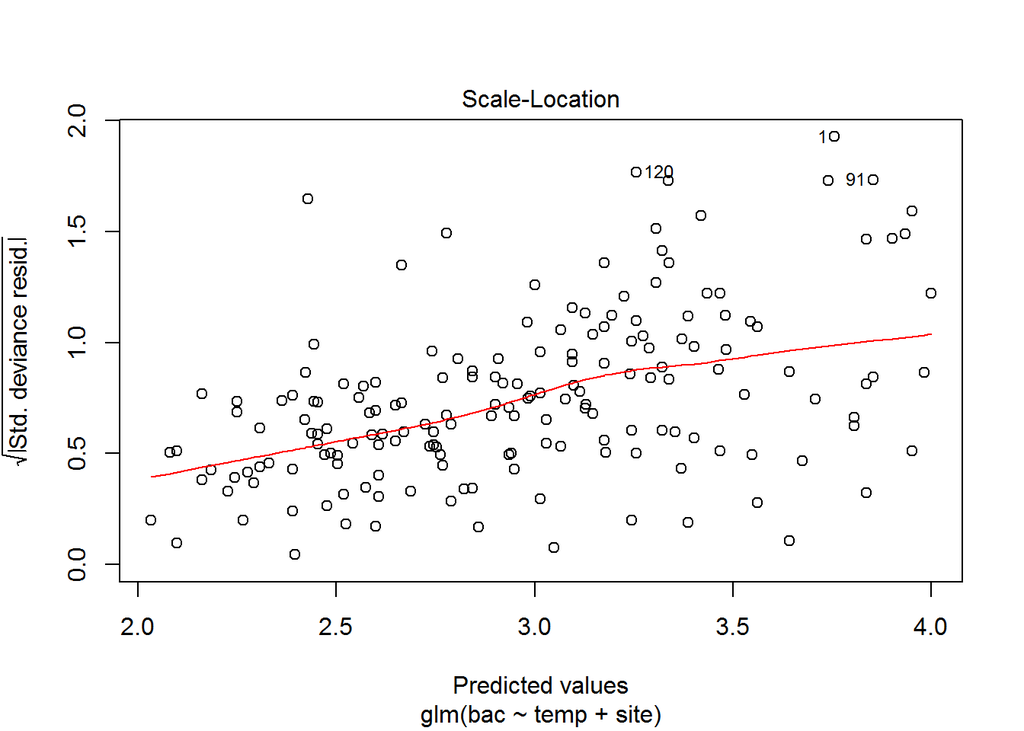

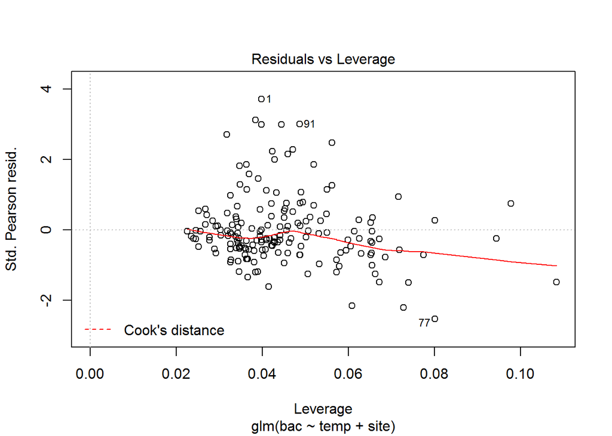

```r
plot(myglm)
```

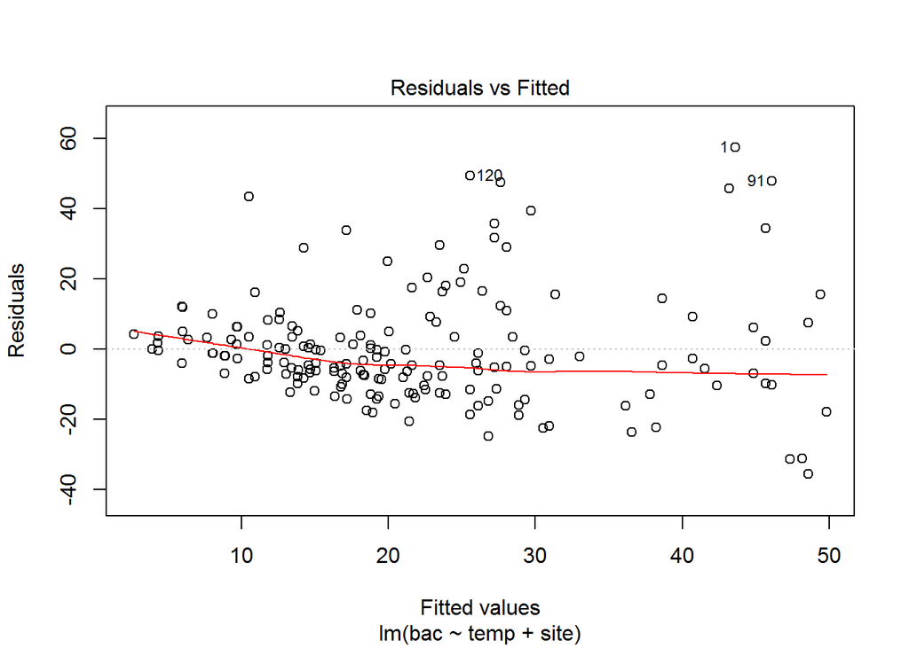

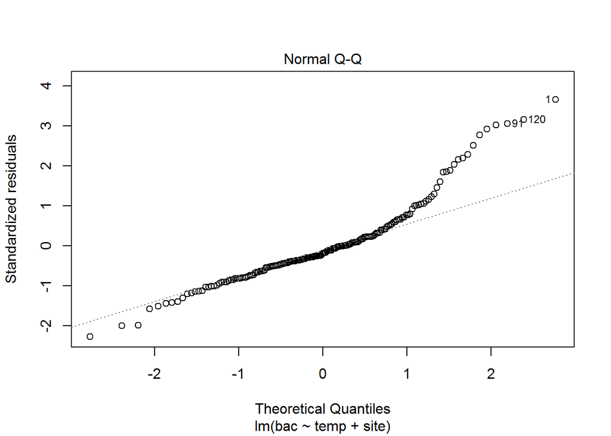

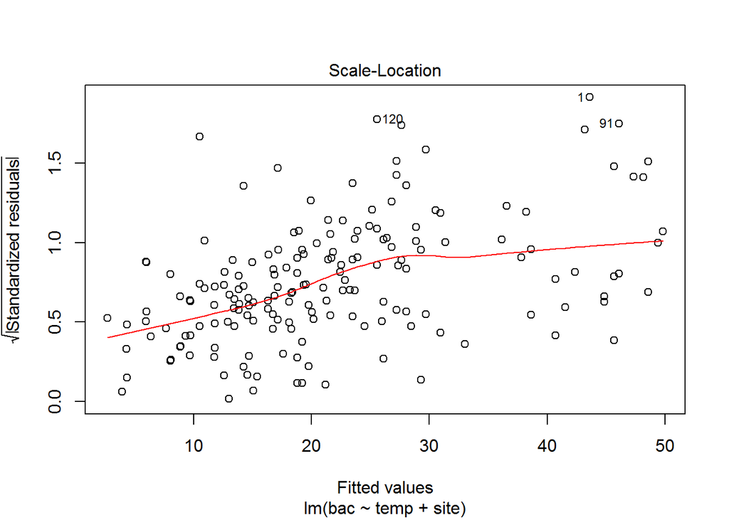

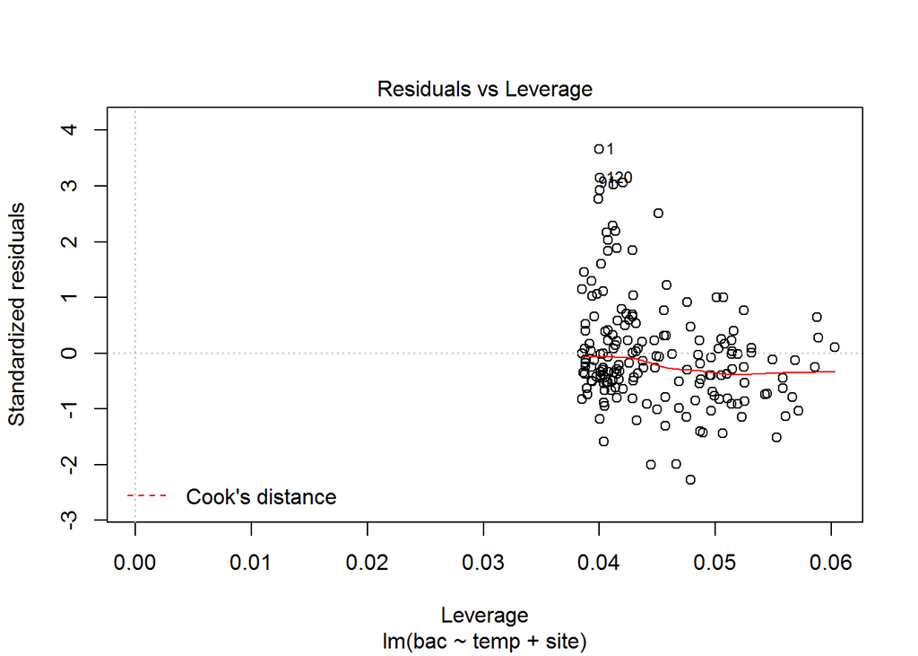

```r
plot(mylm)
```

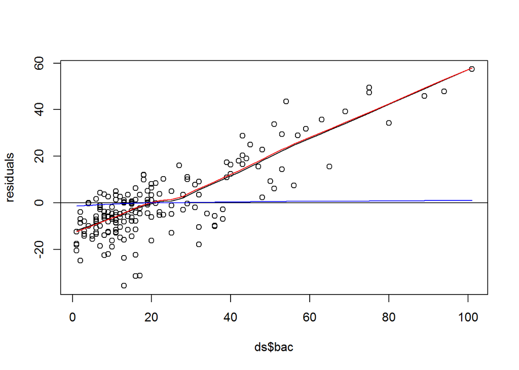

```r
plot(ds$bac, residuals(mylm), ylab="residuals"); abline(0, 0)
lines(lowess(ds$bac, residuals(mylm)))
lines(lowess(ds$bac, residuals(myglm)),col="red")
lines(lowess(ds$bac, residuals(myglm2)),col="blue")
```

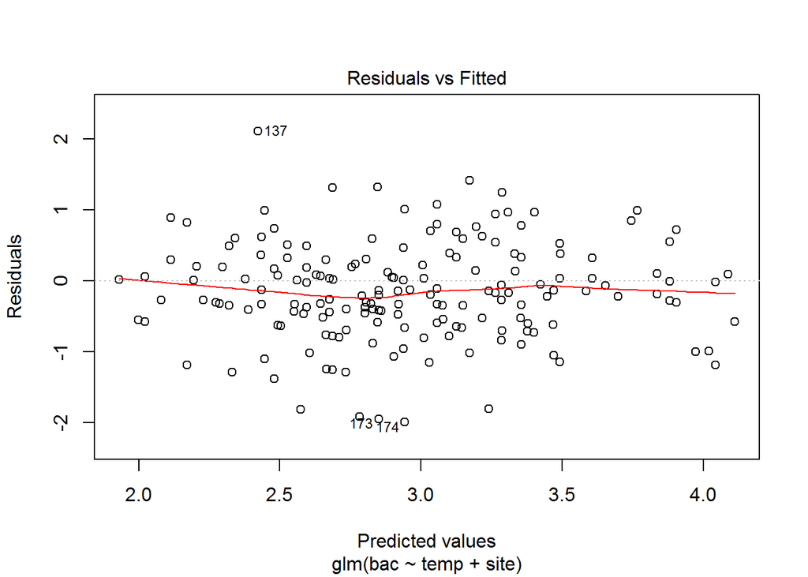

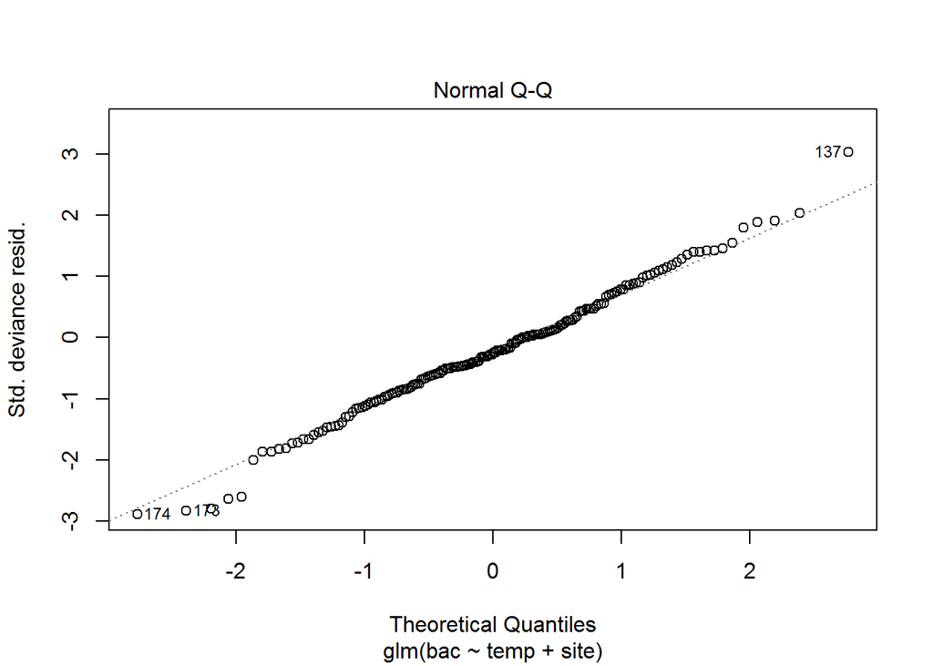

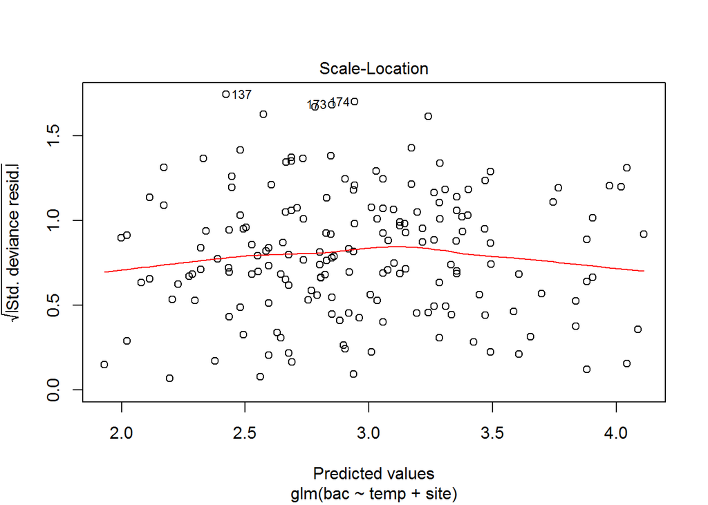

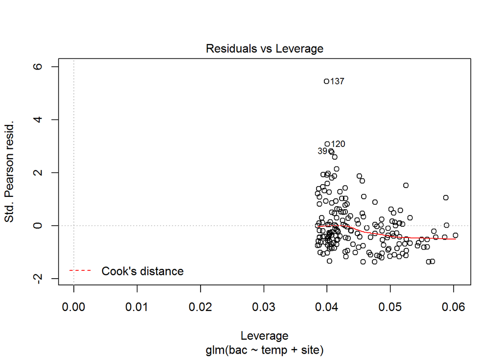

```r
plot(myglm2)
```

Gamma is great. Residuals became smaller.

Prediction regions: site=6, humi=0.6

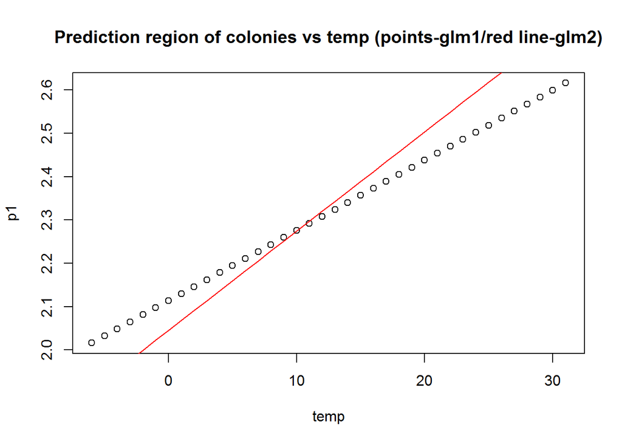

```r
m1<-min(ds$temp)
m2<-max(ds$temp)
temp<-seq(m1,m2,1)
site<-rep(6,38)
test<-data.frame(temp,"site"=as.factor(site))

p1<-predict.glm(myglm,test)
p2<-predict.glm(myglm2,test)

plot(temp,p1,main="Prediction region of colonies vs temp (points-glm1/red line-glm2)")
lines(temp,p2,col="red")
```

# Multilevel Models

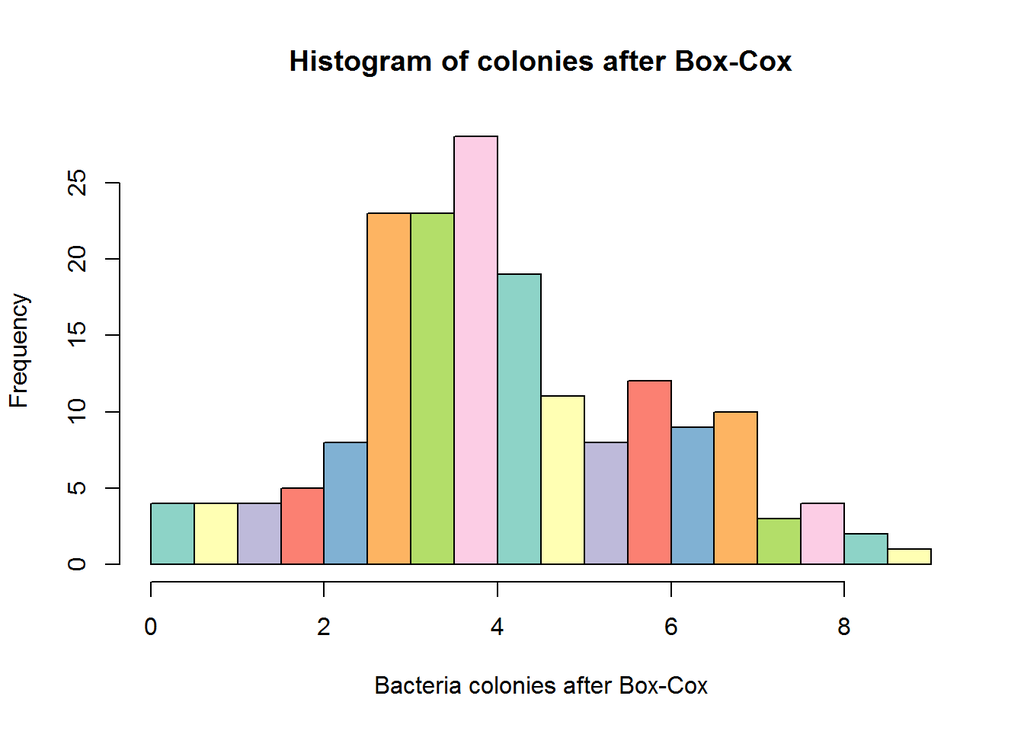

```r
lambda<-1/4
ds$bac_bc<-((ds$bac^lambda)-1)/lambda
hist(ds$bac_bc,breaks=30,col=pal,xlab="Bacteria colonies after Box-Cox",main="Histogram of colonies after Box-Cox") # okay seems to be normal
```

```r
mlmod<- glmer(I(bac_bc+0.0001) ~ site+(temp+humi|date),data=ds,family=gaussian(link="log"))
```

```
## singular fit
```

```r
mlmod2<- glmer(I(bac_bc+0.0001) ~ site+(temp+humi|date),data=ds, family=Gamma(link="log"))
```

```
## singular fit
```

```r
summary(mlmod)
```

```
## Generalized linear mixed model fit by maximum likelihood (Laplace
##   Approximation) [glmerMod]
##  Family: gaussian  ( log )
## Formula: I(bac_bc + 1e-04) ~ site + (temp + humi | date)
##    Data: ds
##
##      AIC      BIC   logLik deviance df.resid
##    655.1    699.6   -313.5    627.1      164
##
## Scaled residuals:
##      Min       1Q   Median       3Q      Max
## -2.48551 -0.67312 -0.01017  0.55276  2.94156
##
## Random effects:
##  Groups   Name        Variance  Std.Dev. Corr
##  date     (Intercept) 1.5457939 1.24330
##           temp        0.0009390 0.03064  -1.00
##           humi        0.0001424 0.01193  -1.00  1.00
##  Residual             1.4851537 1.21867
## Number of obs: 178, groups:  date, 26
##
## Fixed effects:
##             Estimate Std. Error t value Pr(>|z|)
## (Intercept)  1.81900    0.05428  33.513  < 2e-16 ***
## site2       -0.27067    0.06423  -4.214 2.51e-05 ***
## site3       -0.30101    0.06658  -4.521 6.15e-06 ***
## site4       -0.34341    0.06760  -5.080 3.78e-07 ***
## site5       -0.50186    0.07507  -6.685 2.30e-11 ***
## site6       -0.69631    0.08591  -8.105 5.29e-16 ***
## site7       -0.63196    0.08194  -7.713 1.23e-14 ***
## ---
## Signif. codes:  0 '***' 0.001 '**' 0.01 '*' 0.05 '.' 0.1 ' ' 1
##
## Correlation of Fixed Effects:
##       (Intr) site2  site3  site4  site5  site6
## site2 -0.418
## site3 -0.382  0.373
## site4 -0.354  0.362  0.350
## site5 -0.366  0.321  0.311  0.303
## site6 -0.307  0.279  0.271  0.270  0.244
## site7 -0.322  0.296  0.290  0.290  0.250  0.227
## convergence code: 0
## singular fit
```

```r
summary(mlmod2)
```

```
## Generalized linear mixed model fit by maximum likelihood (Laplace
##   Approximation) [glmerMod]
##  Family: Gamma  ( log )
## Formula: I(bac_bc + 1e-04) ~ site + (temp + humi | date)
##    Data: ds
##
##      AIC      BIC   logLik deviance df.resid
##    840.1    884.6   -406.0    812.1      164
##
## Scaled residuals:
##     Min      1Q  Median      3Q     Max
## -2.6606 -0.5400 -0.1267  0.6436  2.8724
##
## Random effects:
##  Groups   Name        Variance  Std.Dev.  Corr
##  date     (Intercept) 3.601e-02 0.1897555
##           temp        6.646e-05 0.0081524 -1.00
##           humi        2.709e-07 0.0005205 -1.00  1.00
##  Residual             1.413e-01 0.3758403
## Number of obs: 178, groups:  date, 26
##
## Fixed effects:
##             Estimate Std. Error t value Pr(>|z|)
## (Intercept)   1.8489     0.1485  12.453  < 2e-16 ***
## site2        -0.3208     0.1980  -1.620 0.105309
## site3        -0.3832     0.2007  -1.909 0.056257 .
## site4        -0.3945     0.1999  -1.974 0.048435 *
## site5        -0.5076     0.1993  -2.547 0.010854 *
## site6        -0.6737     0.1972  -3.417 0.000634 ***
## site7        -0.6611     0.1981  -3.337 0.000847 ***
## ---
## Signif. codes:  0 '***' 0.001 '**' 0.01 '*' 0.05 '.' 0.1 ' ' 1
##
## Correlation of Fixed Effects:
##       (Intr) site2  site3  site4  site5  site6
## site2 -0.699
## site3 -0.696  0.512
## site4 -0.695  0.508  0.505
## site5 -0.682  0.508  0.501  0.501
## site6 -0.680  0.507  0.500  0.502  0.502
## site7 -0.697  0.515  0.510  0.510  0.506  0.507
## convergence code: 0
## singular fit
```

# AIC of all models:

```r
AIC(mylm)
```

```
## [1] 1502.068
```

```r
AIC(mylmBC)
```

```
## [1] 656.3756
```

```r
AIC(myglm)
```

```
## [1] 1501.864
```

```r
AIC(myglm2)
```

```
## [1] 1378.533
```

```r
AIC(mlmod) # best
```

```
## [1] 655.0784
```

```r
AIC(mlmod2)
```

```
## [1] 840.0699
```

# Conclusion

In this case Box-Cox and Multilevel modelling gave us better results. Final diagnostics for mlmod model:

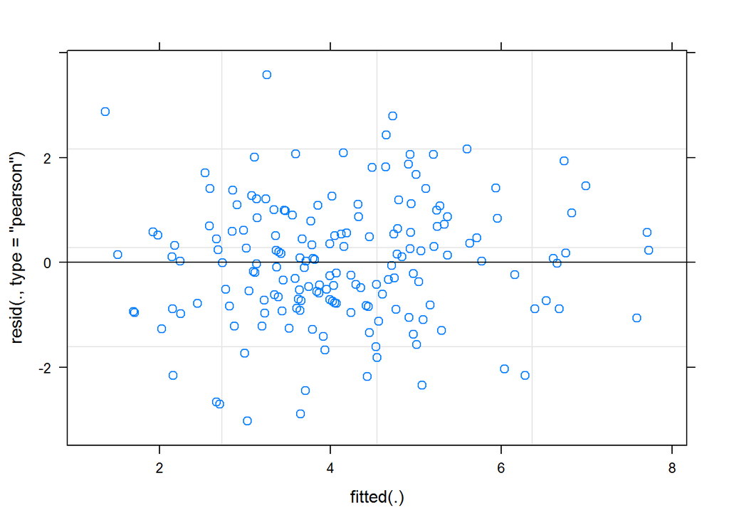

```r
plot(mlmod)
```

The results are similar to Box-Cox transformation.